# Sampling

Xiaochi

08/01/2020

## Sampling bowl activity

### What proportion of this bowl’s balls are red?

### Using the shovel 33 times

```r
tactile_prop_red
```

```
## # A tibble: 33 x 4
##    group            replicate red_balls prop_red
##    <chr>                <int>     <int>    <dbl>
##  1 Ilyas, Yohan             1        21     0.42
##  2 Morgan, Terrance         2        17     0.34
##  3 Martin, Thomas           3        21     0.42
##  4 Clark, Frank             4        21     0.42
##  5 Riddhi, Karina           5        18     0.36
##  6 Andrew, Tyler            6        19     0.38
##  7 Julia                    7        19     0.38
##  8 Rachel, Lauren           8        11     0.22
##  9 Daniel, Caroline         9        15     0.3
## 10 Josh, Maeve             10        17     0.34
## # … with 23 more rows
```

each row can be viewed as one instance of a replicated (in other words repeated) activity: using the shovel to remove 50 balls and computing the proportion of those balls that are red.

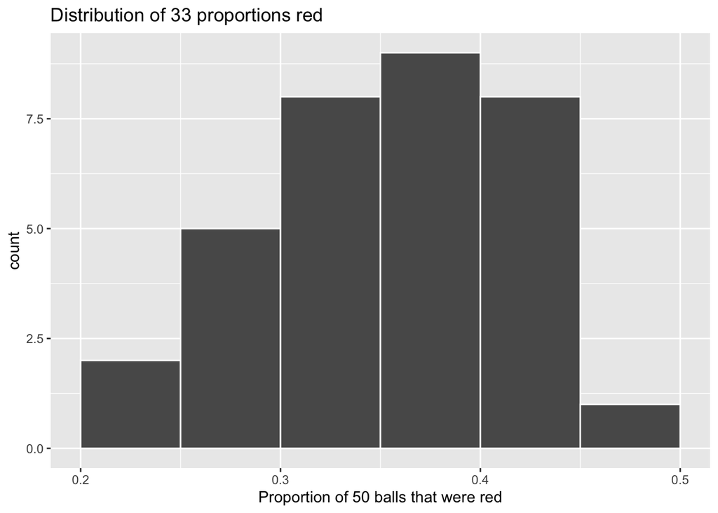

```r
ggplot(tactile_prop_red, aes(x = prop_red)) +
  geom_histogram(binwidth = 0.05, boundary = 0.2,color = "white") +
  labs(x = "Proportion of 50 balls that were red",
       title = "Distribution of 33 proportions red")
```

## Virtual sampling

### Using the virtual shovel once

```r
bowl
```

```
## # A tibble: 2,400 x 2
##    ball_ID color
##      <int> <chr>
##  1       1 white
##  2       2 white
##  3       3 white
##  4       4 red
##  5       5 white
##  6       6 white
##  7       7 red
##  8       8 white
##  9       9 red
## 10      10 white
## # … with 2,390 more rows
```

```r
virtual_shovel <- bowl %>%
  rep_sample_n(size = 50)
virtual_shovel
```

```
## # A tibble: 50 x 3
## # Groups:   replicate [1]
##    replicate ball_ID color
##        <int>   <int> <chr>
##  1         1     619 red
##  2         1    1210 white
##  3         1    1051 red
##  4         1     987 white
##  5         1    1050 red
##  6         1    2345 white
##  7         1     370 white
##  8         1    1722 white
##  9         1    2374 white
## 10         1     736 red
## # … with 40 more rows
```

```r
virtual_shovel %>%
  mutate(is_red = (color == "red"))
```

```
## # A tibble: 50 x 4
## # Groups:   replicate [1]
##    replicate ball_ID color is_red
##        <int>   <int> <chr> <lgl>
##  1         1     619 red   TRUE
##  2         1    1210 white FALSE
##  3         1    1051 red   TRUE
##  4         1     987 white FALSE
##  5         1    1050 red   TRUE
##  6         1    2345 white FALSE
##  7         1     370 white FALSE
##  8         1    1722 white FALSE
##  9         1    2374 white FALSE
## 10         1     736 red   TRUE
## # … with 40 more rows
```

```r
virtual_shovel %>%
  mutate(is_red = (color == "red")) %>%
  summarize(num_red = sum(is_red))
```

```
## # A tibble: 1 x 2
##   replicate num_red
##       <int>   <int>
## 1         1      22
```

```r
virtual_shovel %>%
  mutate(is_red = color == "red") %>%
  summarize(num_red = sum(is_red)) %>%
  mutate(prop_red = num_red / 50)
```

```
## # A tibble: 1 x 3
##   replicate num_red prop_red
##       <int>   <int>    <dbl>
## 1         1      22     0.44
```

```r
virtual_shovel %>%
  summarize(num_red = sum(color == "red")) %>%
  mutate(prop_red = num_red / 50)
```

```
## # A tibble: 1 x 3
##   replicate num_red prop_red
##       <int>   <int>    <dbl>
## 1         1      22     0.44
```

### Using the virtual shovel 33 times

```r
virtual_samples <- bowl %>%
  rep_sample_n(size = 50, reps = 33)
virtual_samples
```

```
## # A tibble: 1,650 x 3
## # Groups:   replicate [33]
##    replicate ball_ID color
##        <int>   <int> <chr>
##  1         1     171 white
##  2         1    1465 red
##  3         1    1113 white
##  4         1     180 white
##  5         1    1882 white
##  6         1    1258 red
##  7         1     364 white
##  8         1     228 white
##  9         1    2024 white
## 10         1    1297 white
## # … with 1,640 more rows
```

```r
50 * 33
```

```
## [1] 1650
```

```r
virtual_prop_red <- virtual_samples %>%
  group_by(replicate) %>%
  summarize(red = sum(color == "red")) %>%
  mutate(prop_red = red / 50)
virtual_prop_red
```

```
## # A tibble: 33 x 3
##    replicate   red prop_red
##        <int> <int>    <dbl>
##  1         1    21     0.42
##  2         2    14     0.28
##  3         3    16     0.32
##  4         4    20     0.4
##  5         5    22     0.44
##  6         6    17     0.34
##  7         7    13     0.26
##  8         8    21     0.42
##  9         9    24     0.48
## 10        10    17     0.34
## # … with 23 more rows
```

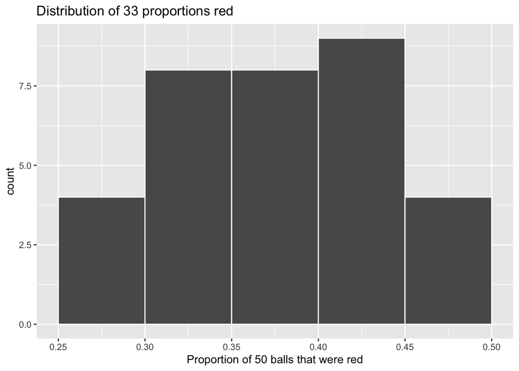

```r
ggplot(virtual_prop_red, aes(x = prop_red)) +
  geom_histogram(binwidth = 0.05, boundary = 0.4, color = "white") +
  labs(x = "Proportion of 50 balls that were red",
       title = "Distribution of 33 proportions red")
```

### Using the virtual shovel 1000 times

```r
virtual_samples <- bowl %>%
  rep_sample_n(size = 50, reps = 1000)
virtual_samples
```

```
## # A tibble: 50,000 x 3
## # Groups:   replicate [1,000]
##    replicate ball_ID color
##        <int>   <int> <chr>
##  1         1    1879 red
##  2         1     997 white
##  3         1    2172 red
##  4         1    1382 red
##  5         1    1137 white
##  6         1    2173 red
##  7         1    1852 red
##  8         1    1405 red
##  9         1    2061 white
## 10         1     600 white
## # … with 49,990 more rows
```

```r
50 * 1000
```

```
## [1] 50000
```

```r
virtual_prop_red <- virtual_samples %>%
  group_by(replicate) %>%
  summarize(red = sum(color == "red")) %>%
  mutate(prop_red = red / 50)
virtual_prop_red
```

```
## # A tibble: 1,000 x 3
##    replicate   red prop_red
##        <int> <int>    <dbl>
##  1         1    19     0.38
##  2         2    22     0.44
##  3         3    18     0.36
##  4         4    24     0.48
##  5         5    14     0.28
##  6         6    16     0.32
##  7         7    16     0.32
##  8         8    15     0.3
##  9         9    22     0.44
## 10        10    14     0.28
## # … with 990 more rows
```

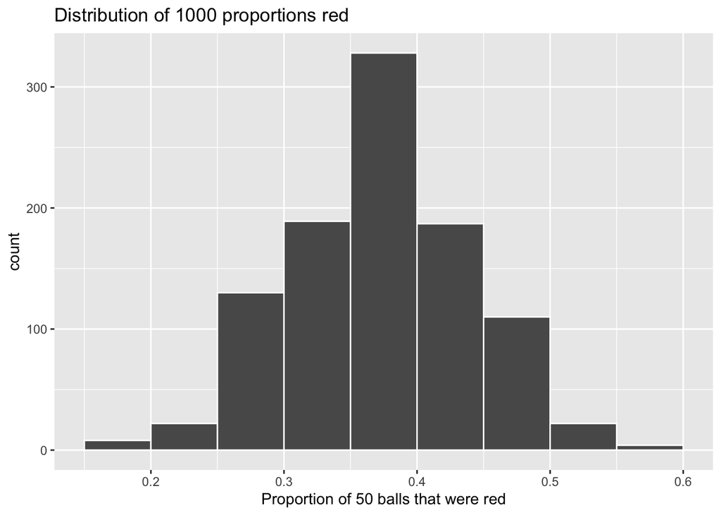

```r
ggplot(virtual_prop_red, aes(x = prop_red)) +
  geom_histogram(binwidth = 0.05, boundary = 0.4, color = "white") +
  labs(x = "Proportion of 50 balls that were red",
       title = "Distribution of 1000 proportions red")
```

According to the Figure, less than 150 out of the 1000 counts were 30% red. So I would say that sampling 50 balls where 30% of them were red is not very likely. Almost no count was only 10% red, so sampling 50 balls where 10% of them were red is extremely unlikely.

### Using different shovels

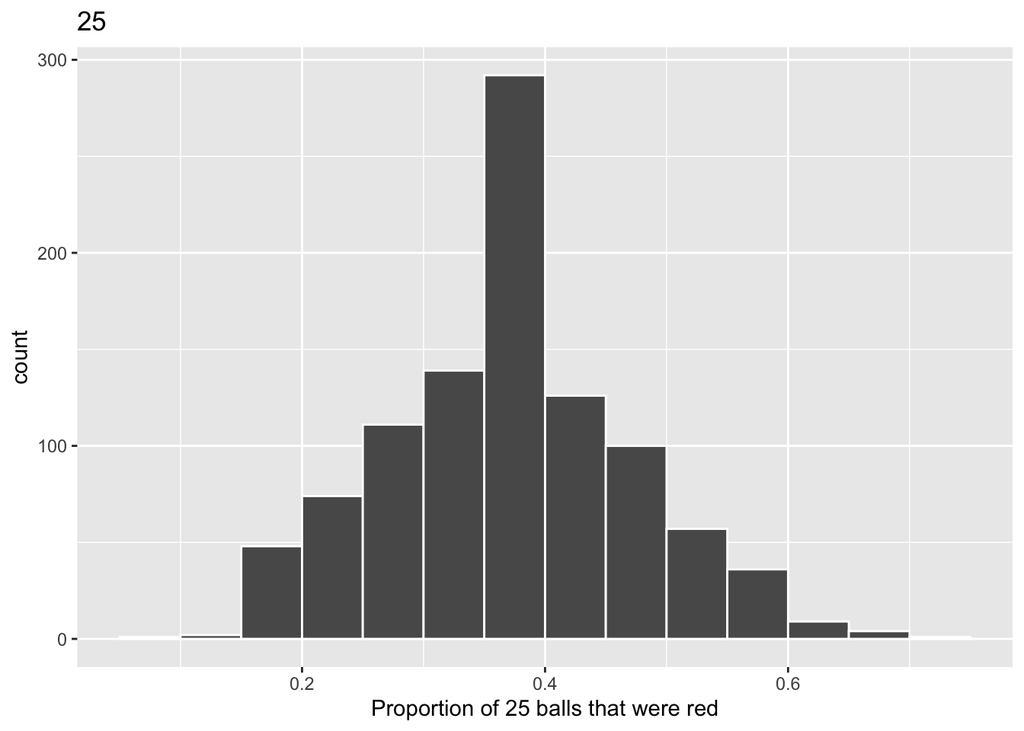

```r
# Segment 1: sample size = 25 ------------------------------
# 1.a) Virtually use shovel 1000 times
virtual_samples_25 <- bowl %>%
  rep_sample_n(size = 25, reps = 1000)

# 1.b) Compute resulting 1000 replicates of proportion red
virtual_prop_red_25 <- virtual_samples_25 %>%
  group_by(replicate) %>%
  summarize(red = sum(color == "red")) %>%
  mutate(prop_red = red / 25)

# 1.c) Plot distribution via a histogram
ggplot(virtual_prop_red_25, aes(x = prop_red)) +
  geom_histogram(binwidth = 0.05, boundary = 0.4, color = "white") +
  labs(x = "Proportion of 25 balls that were red", title = "25")
```

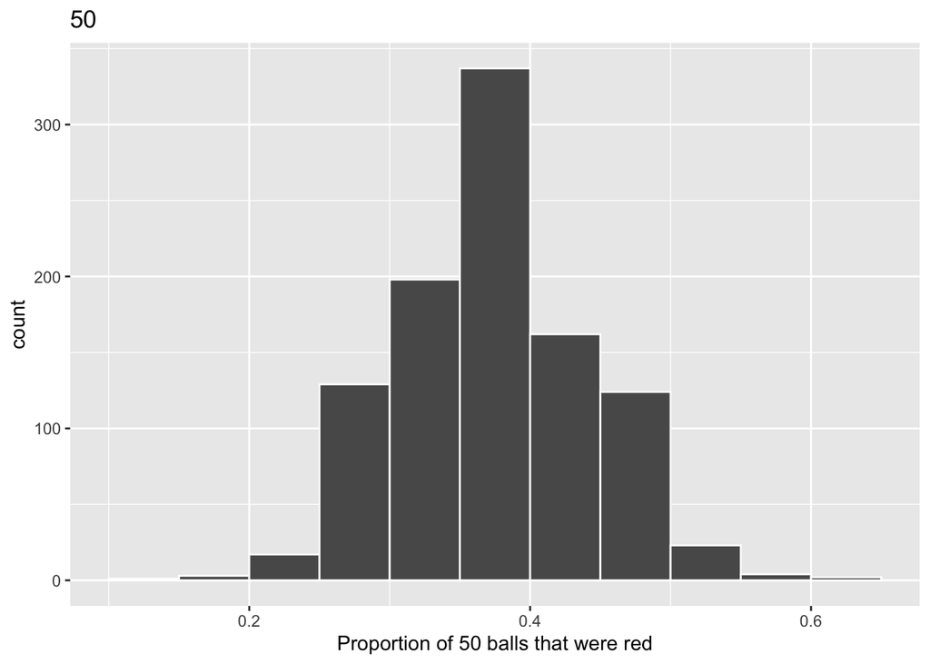

```r
# Segment 2: sample size = 50 ------------------------------
# 2.a) Virtually use shovel 1000 times
virtual_samples_50 <- bowl %>%
  rep_sample_n(size = 50, reps = 1000)

# 2.b) Compute resulting 1000 replicates of proportion red
virtual_prop_red_50 <- virtual_samples_50 %>%
  group_by(replicate) %>%
  summarize(red = sum(color == "red")) %>%
  mutate(prop_red = red / 50)

# 2.c) Plot distribution via a histogram
ggplot(virtual_prop_red_50, aes(x = prop_red)) +
  geom_histogram(binwidth = 0.05, boundary = 0.4, color = "white") +
  labs(x = "Proportion of 50 balls that were red", title = "50")
```

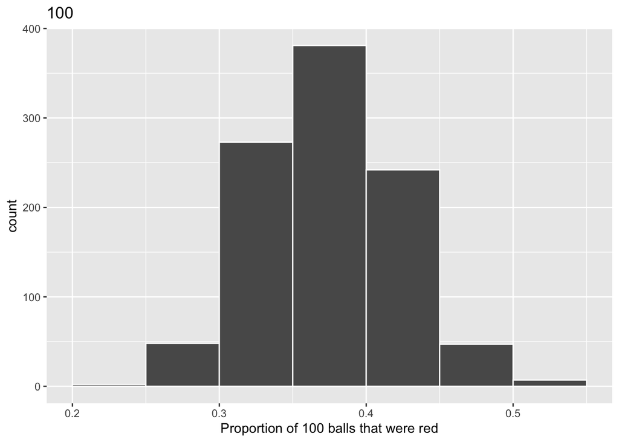

```r
# Segment 3: sample size = 100 ------------------------------
# 3.a) Virtually using shovel with 100 slots 1000 times
virtual_samples_100 <- bowl %>%
  rep_sample_n(size = 100, reps = 1000)


# 3.b) Compute resulting 1000 replicates of proportion red
virtual_prop_red_100 <- virtual_samples_100 %>%
  group_by(replicate) %>%
  summarize(red = sum(color == "red")) %>%
  mutate(prop_red = red / 100)

# 3.c) Plot distribution via a histogram
ggplot(virtual_prop_red_100, aes(x = prop_red)) +
  geom_histogram(binwidth = 0.05, boundary = 0.4, color = "white") +
  labs(x = "Proportion of 100 balls that were red", title = "100")
```

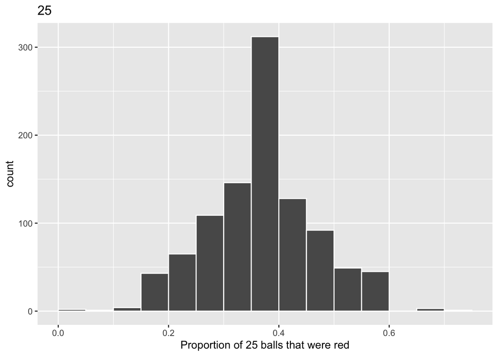

```r
# Segment 1: sample size = 25 ------------------------------
# 1.a) Virtually use shovel 1000 times
virtual_samples_25 <- bowl %>%
  rep_sample_n(size = 25, reps = 1000)

# 1.b) Compute resulting 1000 replicates of proportion red
virtual_prop_red_25 <- virtual_samples_25 %>%
  group_by(replicate) %>%
  summarize(red = sum(color == "red")) %>%
  mutate(prop_red = red / 25)

# 1.c) Plot distribution via a histogram
ggplot(virtual_prop_red_25, aes(x = prop_red)) +
  geom_histogram(binwidth = 0.05, boundary = 0.4, color = "white") +
  labs(x = "Proportion of 25 balls that were red", title = "25")
```

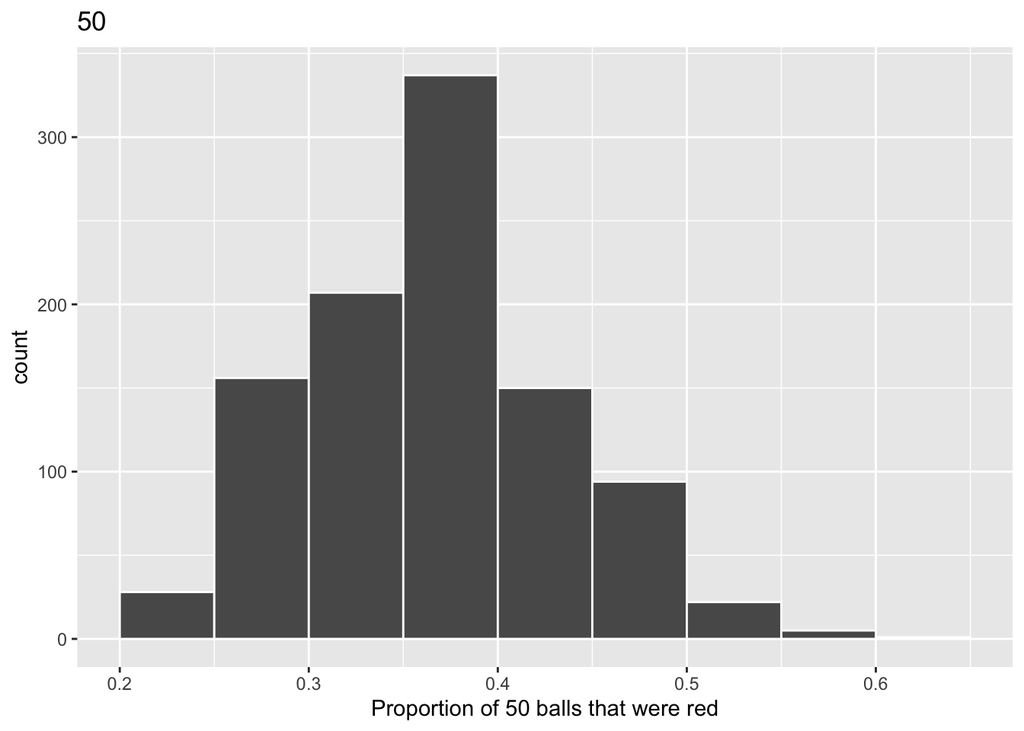

```r
# Segment 2: sample size = 50 ------------------------------
# 2.a) Virtually use shovel 1000 times
virtual_samples_50 <- bowl %>%
  rep_sample_n(size = 50, reps = 1000)

# 2.b) Compute resulting 1000 replicates of proportion red
virtual_prop_red_50 <- virtual_samples_50 %>%
  group_by(replicate) %>%
  summarize(red = sum(color == "red")) %>%
  mutate(prop_red = red / 50)

# 2.c) Plot distribution via a histogram
ggplot(virtual_prop_red_50, aes(x = prop_red)) +
  geom_histogram(binwidth = 0.05, boundary = 0.4, color = "white") +
  labs(x = "Proportion of 50 balls that were red", title = "50")
```

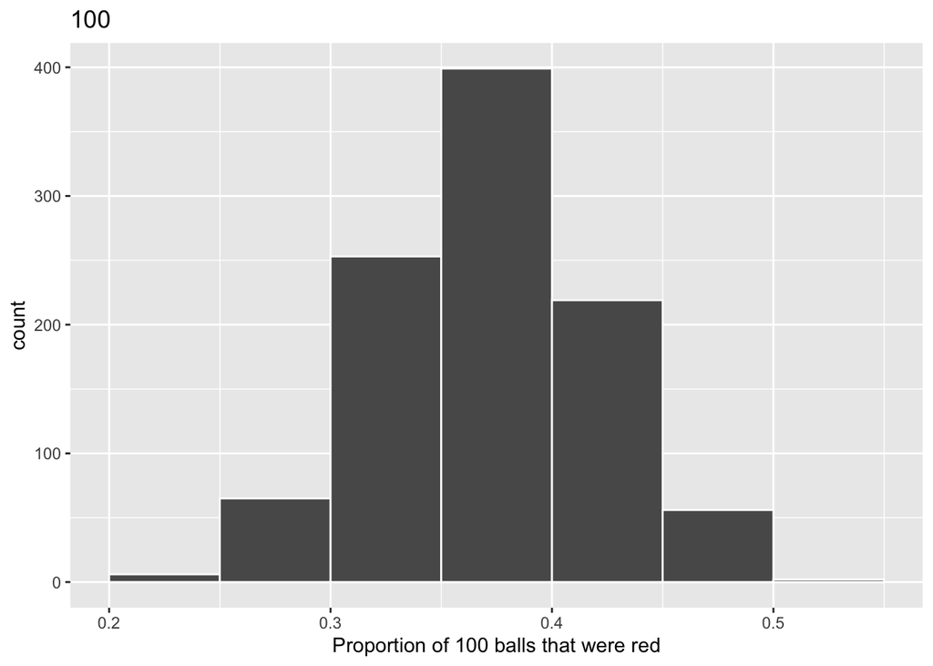

```r
# Segment 3: sample size = 100 ------------------------------
# 3.a) Virtually using shovel with 100 slots 1000 times
virtual_samples_100 <- bowl %>%
  rep_sample_n(size = 100, reps = 1000)

# 3.b) Compute resulting 1000 replicates of proportion red
virtual_prop_red_100 <- virtual_samples_100 %>%
  group_by(replicate) %>%
  summarize(red = sum(color == "red")) %>%
  mutate(prop_red = red / 100)

# 3.c) Plot distribution via a histogram
ggplot(virtual_prop_red_100, aes(x = prop_red)) +
  geom_histogram(binwidth = 0.05, boundary = 0.4, color = "white") +
  labs(x = "Proportion of 100 balls that were red", title = "100")
```

Observe that as the sample size increases, the variation of the 1000 replicates of the proportion of red decreases. In other words, as the sample size increases, there are fewer differences due to sampling variation and the distribution centers more tightly around the same value

```r
# n = 25
virtual_prop_red_25 %>%
  summarize(sd = sd(prop_red))
```

```
## # A tibble: 1 x 1
##       sd
##    <dbl>
## 1 0.0984
```

```r
# n = 50
virtual_prop_red_50 %>%
  summarize(sd = sd(prop_red))
```

```
## # A tibble: 1 x 1
##       sd
##    <dbl>
## 1 0.0678
```

```r
# n = 100
virtual_prop_red_100 %>%
  summarize(sd = sd(prop_red))
```

```
## # A tibble: 1 x 1
##       sd
##    <dbl>
## 1 0.0480
```

## Sampling framework

### Statistical definitions

First, a **population** is a collection of individuals or observations we are interested in. This is also commonly denoted as a study population. We mathematically denote the population’s size using upper-case $N$. In our sampling activities, the (study) population is the collection of $N=2400$ identically sized red and white balls contained in the bowl.

Second, a **population parameter** is a numerical summary quantity about the population that is unknown, but you wish you knew.